# Factors affecting our health: Data Analysis with Logistic Regression

Yuean Wang

# 1 Intro

What affects our health? Apart from obvious answers such as weight, age, BMI, could there be other factors that we normally wouldn’t expect to affect our health deeply? And also among these factors that can influence our health, what are the most significant factors and how are they going to influence our health?  
To answer these questions, we will be using `Logistic Regression Model` to analyze the relationships between different influencer and our health. And to optimize our model, we will be using `cross-validation` as well as `decision tree pruning` to further improve our prediction.

# 2 Data Handling

## 2.1 Collecting data

The original dataset was collected by the US National Health and Nutrition Examination Study in 2011. See [Here](https://cran.r-project.org/web/packages/NHANES/NHANES.pdf) for more detailed information.  
Since we would like to predict on the variable `HealthGen`, a variable that represents the health of the participant in general, we will only select 17 variables from the original data set: `Gender`,`Age`,`Race1`,`Education`,`MaritalStatus`,`HHIncome`,`BMI_WHO`,`HealthGen`,`Depressed`, `SleepTrouble`,`PhysActiveDays`,`TVHrsDay`,`CompHrsDay`,`AlcoholYear`,`SmokeNow`,`RegularMarij`, `SexOrientation`  
For our analysis, we only select entries from the year 2011 and from participants who’s age is within 18 and 59.

```r
library(dplyr)
library(kableExtra)
library(tidyverse)
library(ggpubr)
library(fastmatch)
require(knitr)
require(table1)
require(cvTools)
library(NHANES)
library(car)
library("pROC")
library(rsq)
require(rpart)
require(tree)

dat <- NHANES
SurveyYr <- NHANES$SurveyYr

# select the observations that is in year 2011
dat <- dat[SurveyYr=="2011_12", ]
age <- dat$Age

# select the obervations with age between 18 and 59
dat <- dat[(age >= 18) & (age <= 59), ]

# select the variables
ind <- c("Gender","Age","Race1","Education","MaritalStatus","HHIncome",
          "BMI_WHO","HealthGen","Depressed","SleepTrouble","PhysActiveDays",
          "TVHrsDay","CompHrsDay","AlcoholYear","SmokeNow","RegularMarij",
          "SexOrientation")
dat <- dat[,ind]
head(dat)
```

| Gender | Age | Race1 | Education | MaritalStatus | HHIncome | BMI_WHO | HealthGen | Depressed | SleepTrouble | PhysActiveDays | TVHrsDay | CompHrsDay | AlcoholYear | SmokeNow | RegularMarij | SexOrientation |
| --- | --- | --- | --- | --- | --- | --- | --- | --- | --- | --- | --- | --- | --- | --- | --- | --- |
| female | 43 | Black | High School | NeverMarried | 20000-24999 | 30.0_plus | Good | Most | No | 2 | More_4_hr | More_4_hr | 104 | Yes | No | Heterosexual |
| female | 34 | White | College Grad | Married | more 99999 | 18.5_to_24.9 | Vgood | None | No | 5 | 2_hr | 0_to_1_hr | 104 | NA | No | Heterosexual |
| male | 35 | White | College Grad | Married | 20000-24999 | 25.0_to_29.9 | Good | Several | Yes | NA | 2_hr | 1_hr | 2 | NA | No | Heterosexual |
| male | 57 | White | College Grad | LivePartner | more 99999 | 25.0_to_29.9 | Vgood | None | No | 2 | 1_hr | 1_hr | 260 | No | No | Homosexual |
| male | 57 | White | College Grad | LivePartner | more 99999 | 25.0_to_29.9 | Vgood | None | No | NA | 1_hr | 1_hr | 260 | No | No | Homosexual |
| male | 57 | White | College Grad | LivePartner | more 99999 | 25.0_to_29.9 | Vgood | None | No | 7 | 1_hr | 1_hr | 260 | No | No | Homosexual |

The result dataset contains 2783 observations with 17 variables.

## 2.2 Cleaning data

Notice that there are several invalid response from the dataset. Let’s take a holistic view of the null values in the dataset

```r
na_count <- sapply(dat, function(x) sum(is.na(x)))
na_count <- data.frame(na_count)
kable(na_count) %>% kable_styling(bootstrap_options ="striped", full_width = FALSE)
```

|  | na_count |
| --- | --- |
| Gender | 0 |
| Age | 0 |
| Race1 | 0 |
| Education | 120 |
| MaritalStatus | 120 |
| HHIncome | 224 |
| BMI_WHO | 24 |
| HealthGen | 310 |
| Depressed | 316 |
| SleepTrouble | 0 |
| PhysActiveDays | 1458 |
| TVHrsDay | 0 |
| CompHrsDay | 0 |
| AlcoholYear | 542 |
| SmokeNow | 1692 |
| RegularMarij | 340 |
| SexOrientation | 381 |

First we need to ensure that there aren’t any missing value in the column `HealthGen`, as it is our predictor.  
Then by looking at the number of invalid entries, we decided to drop the variables `PhysActiveDays`, `SmokeNow` and `AlcoholYear`, as they each have over 500 invalid values. With these three variables included in the dataset, we would be removing more data entries later on.  
Lastly we proceed to omit any rows that contains missing value, now we are left with a dataset with 2,118 rows and 14 columns

```r
# Drop rows with missing outcomes (HealthGenNum)
dat = dat[complete.cases(dat[, 'HealthGen']),]

# Drop SmokeNow, PhysActiveDays and AlcoholYear
dat = dat[, !(ind %in% c('SmokeNow', 'PhysActiveDays','AlcoholYear'))]
ind = names(dat)
#omit rows with missing values
dat = na.omit(dat)
summary(dat)
```

```
##     Gender          Age             Race1               Education
##  female: 984   Min.   :20.00   Black   : 222   8th Grade     : 56
##  male  :1134   1st Qu.:29.00   Hispanic: 129   9 - 11th Grade:216
##                Median :40.00   Mexican : 176   High School   :390
##                Mean   :39.67   White   :1422   Some College  :710
##                3rd Qu.:50.00   Other   : 169   College Grad  :746
##                Max.   :59.00
##
##       MaritalStatus         HHIncome           BMI_WHO        HealthGen
##  Divorced    : 212   more 99999 :597   12.0_18.5   : 31   Excellent:256
##  LivePartner : 213   75000-99999:262   18.5_to_24.9:642   Vgood    :714
##  Married     :1072   25000-34999:203   25.0_to_29.9:685   Good     :861
##  NeverMarried: 551   35000-44999:201   30.0_plus   :760   Fair     :256
##  Separated   :  50   45000-54999:183                      Poor     : 31
##  Widowed     :  20   65000-74999:139
##                      (Other)    :533
##    Depressed    SleepTrouble      TVHrsDay       CompHrsDay  RegularMarij
##  None   :1678   No :1552     0_hrs    : 47   0_hrs    :297   No :1523
##  Several: 299   Yes: 566     0_to_1_hr:315   0_to_1_hr:637   Yes: 595
##  Most   : 141                1_hr     :406   1_hr     :501
##                              2_hr     :568   2_hr     :286
##                              3_hr     :327   3_hr     :164
##                              4_hr     :209   4_hr     :101
##                              More_4_hr:246   More_4_hr:132
##       SexOrientation
##  Bisexual    :  51
##  Heterosexual:2021
##  Homosexual  :  46
##
##
##
##
```

## 2.3 Descriptive summary of the data

Now let’s look at a statistical summary of the candidate variables vs HealthGen.

```r
# Make Table 1
table1(~ Gender + Age + Race1 + Education + MaritalStatus + HHIncome + BMI_WHO +
         Depressed + SleepTrouble + TVHrsDay + CompHrsDay + RegularMarij +
         SexOrientation | HealthGen, data=dat,output = "html")
```

|  | Excellent (N=256) | Vgood (N=714) | Good (N=861) | Fair (N=256) | Poor (N=31) | Overall (N=2118) |
| --- | --- | --- | --- | --- | --- | --- |
| Gender |  |  |  |  |  |  |
| female | 127 (49.6%) | 348 (48.7%) | 367 (42.6%) | 123 (48.0%) | 19 (61.3%) | 984 (46.5%) |
| male | 129 (50.4%) | 366 (51.3%) | 494 (57.4%) | 133 (52.0%) | 12 (38.7%) | 1134 (53.5%) |
| Age |  |  |  |  |  |  |
| Mean (SD) | 35.9 (10.8) | 39.2 (12.0) | 40.1 (11.3) | 42.8 (11.9) | 45.0 (11.5) | 39.7 (11.7) |
| Median [Min, Max] | 34.0 [20.0, 59.0] | 39.0 [20.0, 59.0] | 41.0 [20.0, 59.0] | 46.0 [20.0, 59.0] | 50.0 [23.0, 59.0] | 40.0 [20.0, 59.0] |
| Race1 |  |  |  |  |  |  |
| Black | 27 (10.5%) | 61 (8.5%) | 84 (9.8%) | 42 (16.4%) | 8 (25.8%) | 222 (10.5%) |
| Hispanic | 11 (4.3%) | 25 (3.5%) | 72 (8.4%) | 19 (7.4%) | 2 (6.5%) | 129 (6.1%) |
| Mexican | 15 (5.9%) | 44 (6.2%) | 73 (8.5%) | 39 (15.2%) | 5 (16.1%) | 176 (8.3%) |
| White | 184 (71.9%) | 528 (73.9%) | 559 (64.9%) | 138 (53.9%) | 13 (41.9%) | 1422 (67.1%) |
| Other | 19 (7.4%) | 56 (7.8%) | 73 (8.5%) | 18 (7.0%) | 3 (9.7%) | 169 (8.0%) |
| Education |  |  |  |  |  |  |
| 8th Grade | 4 (1.6%) | 5 (0.7%) | 23 (2.7%) | 23 (9.0%) | 1 (3.2%) | 56 (2.6%) |
| 9 - 11th Grade | 11 (4.3%) | 47 (6.6%) | 102 (11.8%) | 50 (19.5%) | 6 (19.4%) | 216 (10.2%) |
| High School | 32 (12.5%) | 111 (15.5%) | 180 (20.9%) | 62 (24.2%) | 5 (16.1%) | 390 (18.4%) |
| Some College | 69 (27.0%) | 240 (33.6%) | 312 (36.2%) | 77 (30.1%) | 12 (38.7%) | 710 (33.5%) |
| College Grad | 140 (54.7%) | 311 (43.6%) | 244 (28.3%) | 44 (17.2%) | 7 (22.6%) | 746 (35.2%) |
| MaritalStatus |  |  |  |  |  |  |
| Divorced | 16 (6.2%) | 56 (7.8%) | 93 (10.8%) | 43 (16.8%) | 4 (12.9%) | 212 (10.0%) |
| LivePartner | 19 (7.4%) | 78 (10.9%) | 83 (9.6%) | 31 (12.1%) | 2 (6.5%) | 213 (10.1%) |
| Married | 129 (50.4%) | 391 (54.8%) | 434 (50.4%) | 103 (40.2%) | 15 (48.4%) | 1072 (50.6%) |
| NeverMarried | 81 (31.6%) | 172 (24.1%) | 228 (26.5%) | 62 (24.2%) | 8 (25.8%) | 551 (26.0%) |
| Separated | 10 (3.9%) | 12 (1.7%) | 12 (1.4%) | 14 (5.5%) | 2 (6.5%) | 50 (2.4%) |
| Widowed | 1 (0.4%) | 5 (0.7%) | 11 (1.3%) | 3 (1.2%) | 0 (0%) | 20 (0.9%) |
| HHIncome |  |  |  |  |  |  |
| 0-4999 | 5 (2.0%) | 11 (1.5%) | 12 (1.4%) | 10 (3.9%) | 3 (9.7%) | 41 (1.9%) |
| 5000-9999 | 3 (1.2%) | 13 (1.8%) | 17 (2.0%) | 9 (3.5%) | 3 (9.7%) | 45 (2.1%) |
| 10000-14999 | 10 (3.9%) | 16 (2.2%) | 52 (6.0%) | 24 (9.4%) | 5 (16.1%) | 107 (5.1%) |
| 15000-19999 | 8 (3.1%) | 24 (3.4%) | 51 (5.9%) | 26 (10.2%) | 6 (19.4%) | 115 (5.4%) |
| 20000-24999 | 8 (3.1%) | 31 (4.3%) | 45 (5.2%) | 23 (9.0%) | 3 (9.7%) | 110 (5.2%) |
| 25000-34999 | 14 (5.5%) | 61 (8.5%) | 94 (10.9%) | 33 (12.9%) | 1 (3.2%) | 203 (9.6%) |
| 35000-44999 | 18 (7.0%) | 51 (7.1%) | 101 (11.7%) | 27 (10.5%) | 4 (12.9%) | 201 (9.5%) |
| 45000-54999 | 21 (8.2%) | 64 (9.0%) | 73 (8.5%) | 24 (9.4%) | 1 (3.2%) | 183 (8.6%) |
| 55000-64999 | 12 (4.7%) | 37 (5.2%) | 58 (6.7%) | 7 (2.7%) | 1 (3.2%) | 115 (5.4%) |
| 65000-74999 | 11 (4.3%) | 50 (7.0%) | 67 (7.8%) | 10 (3.9%) | 1 (3.2%) | 139 (6.6%) |
| 75000-99999 | 42 (16.4%) | 114 (16.0%) | 88 (10.2%) | 18 (7.0%) | 0 (0%) | 262 (12.4%) |
| more 99999 | 104 (40.6%) | 242 (33.9%) | 203 (23.6%) | 45 (17.6%) | 3 (9.7%) | 597 (28.2%) |
| BMI_WHO |  |  |  |  |  |  |
| 12.0_18.5 | 3 (1.2%) | 9 (1.3%) | 14 (1.6%) | 5 (2.0%) | 0 (0%) | 31 (1.5%) |
| 18.5_to_24.9 | 136 (53.1%) | 260 (36.4%) | 184 (21.4%) | 59 (23.0%) | 3 (9.7%) | 642 (30.3%) |
| 25.0_to_29.9 | 74 (28.9%) | 277 (38.8%) | 266 (30.9%) | 58 (22.7%) | 10 (32.3%) | 685 (32.3%) |
| 30.0_plus | 43 (16.8%) | 168 (23.5%) | 397 (46.1%) | 134 (52.3%) | 18 (58.1%) | 760 (35.9%) |
| Depressed |  |  |  |  |  |  |
| None | 240 (93.8%) | 617 (86.4%) | 652 (75.7%) | 157 (61.3%) | 12 (38.7%) | 1678 (79.2%) |
| Several | 12 (4.7%) | 73 (10.2%) | 138 (16.0%) | 66 (25.8%) | 10 (32.3%) | 299 (14.1%) |
| Most | 4 (1.6%) | 24 (3.4%) | 71 (8.2%) | 33 (12.9%) | 9 (29.0%) | 141 (6.7%) |
| SleepTrouble |  |  |  |  |  |  |
| No | 219 (85.5%) | 574 (80.4%) | 602 (69.9%) | 145 (56.6%) | 12 (38.7%) | 1552 (73.3%) |
| Yes | 37 (14.5%) | 140 (19.6%) | 259 (30.1%) | 111 (43.4%) | 19 (61.3%) | 566 (26.7%) |
| TVHrsDay |  |  |  |  |  |  |
| 0_hrs | 6 (2.3%) | 15 (2.1%) | 11 (1.3%) | 15 (5.9%) | 0 (0%) | 47 (2.2%) |
| 0_to_1_hr | 63 (24.6%) | 123 (17.2%) | 108 (12.5%) | 20 (7.8%) | 1 (3.2%) | 315 (14.9%) |
| 1_hr | 38 (14.8%) | 153 (21.4%) | 179 (20.8%) | 32 (12.5%) | 4 (12.9%) | 406 (19.2%) |
| 2_hr | 78 (30.5%) | 195 (27.3%) | 216 (25.1%) | 71 (27.7%) | 8 (25.8%) | 568 (26.8%) |
| 3_hr | 37 (14.5%) | 115 (16.1%) | 127 (14.8%) | 45 (17.6%) | 3 (9.7%) | 327 (15.4%) |
| 4_hr | 24 (9.4%) | 63 (8.8%) | 83 (9.6%) | 37 (14.5%) | 2 (6.5%) | 209 (9.9%) |
| More_4_hr | 10 (3.9%) | 50 (7.0%) | 137 (15.9%) | 36 (14.1%) | 13 (41.9%) | 246 (11.6%) |
| CompHrsDay |  |  |  |  |  |  |
| 0_hrs | 22 (8.6%) | 76 (10.6%) | 126 (14.6%) | 61 (23.8%) | 12 (38.7%) | 297 (14.0%) |
| 0_to_1_hr | 74 (28.9%) | 213 (29.8%) | 274 (31.8%) | 69 (27.0%) | 7 (22.6%) | 637 (30.1%) |
| 1_hr | 57 (22.3%) | 210 (29.4%) | 182 (21.1%) | 49 (19.1%) | 3 (9.7%) | 501 (23.7%) |
| 2_hr | 55 (21.5%) | 94 (13.2%) | 108 (12.5%) | 24 (9.4%) | 5 (16.1%) | 286 (13.5%) |
| 3_hr | 21 (8.2%) | 53 (7.4%) | 64 (7.4%) | 25 (9.8%) | 1 (3.2%) | 164 (7.7%) |
| 4_hr | 16 (6.2%) | 28 (3.9%) | 42 (4.9%) | 13 (5.1%) | 2 (6.5%) | 101 (4.8%) |
| More_4_hr | 11 (4.3%) | 40 (5.6%) | 65 (7.5%) | 15 (5.9%) | 1 (3.2%) | 132 (6.2%) |
| RegularMarij |  |  |  |  |  |  |
| No | 210 (82.0%) | 526 (73.7%) | 611 (71.0%) | 153 (59.8%) | 23 (74.2%) | 1523 (71.9%) |
| Yes | 46 (18.0%) | 188 (26.3%) | 250 (29.0%) | 103 (40.2%) | 8 (25.8%) | 595 (28.1%) |
| SexOrientation |  |  |  |  |  |  |
| Bisexual | 3 (1.2%) | 22 (3.1%) | 18 (2.1%) | 8 (3.1%) | 0 (0%) | 51 (2.4%) |
| Heterosexual | 250 (97.7%) | 671 (94.0%) | 823 (95.6%) | 247 (96.5%) | 30 (96.8%) | 2021 (95.4%) |
| Homosexual | 3 (1.2%) | 21 (2.9%) | 20 (2.3%) | 1 (0.4%) | 1 (3.2%) | 46 (2.2%) |

Upon closely examining the statistic table, I found out that the distribution of `SexOrientation` is extremely unbalanced.

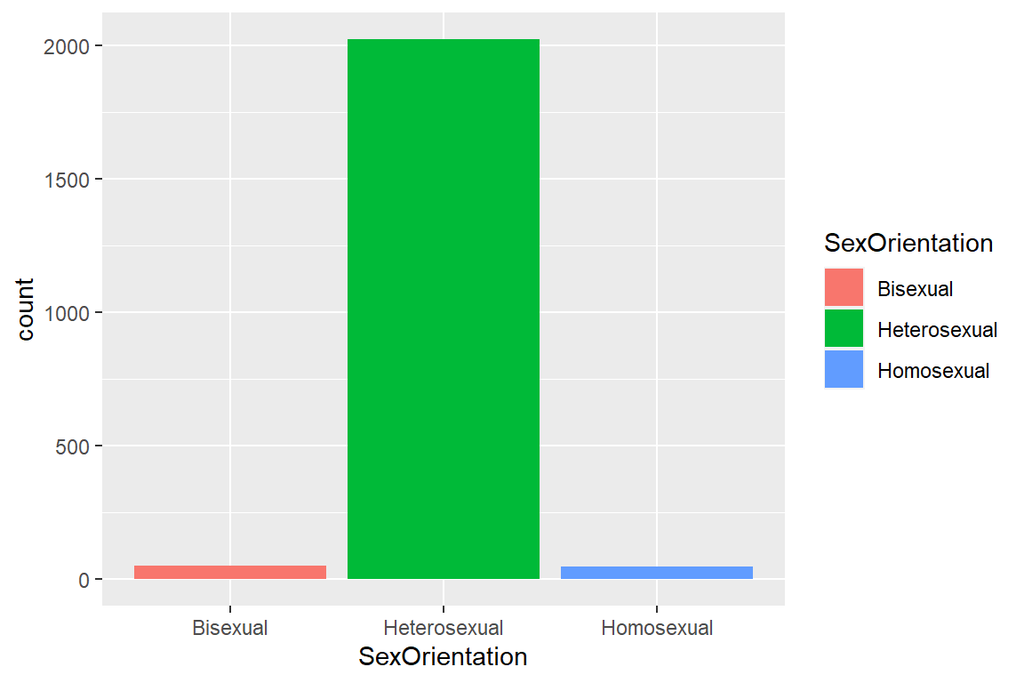

```r
ggplot(dat)+
  geom_histogram(mapping=aes(x=SexOrientation,fill=SexOrientation),stat="count")
```

As a result, we will be dropping `SexOrientation` from our analysis.  
Remained factors:

```
##  [1] "Gender"        "Age"           "Race1"         "Education"
##  [5] "MaritalStatus" "HHIncome"      "BMI_WHO"       "HealthGen"
##  [9] "Depressed"     "SleepTrouble"  "TVHrsDay"      "CompHrsDay"
## [13] "RegularMarij"
```

# 3 Building Model

In this study we will be the step-wise selection procedure.

## 3.1 Prescreening

Notice that `HealthGen` is categorized into five response, `Excellent`, `Vgood`, `Good`, `Fair`, and `Poor`. In order to simplify the analysis process and to conduct logistics regression, we will be convert HealthGen into a binary variable, `Excellent/Vgood` VS `Good/Fair/Poor`, with `1` representing `Excellent/Vgood`.

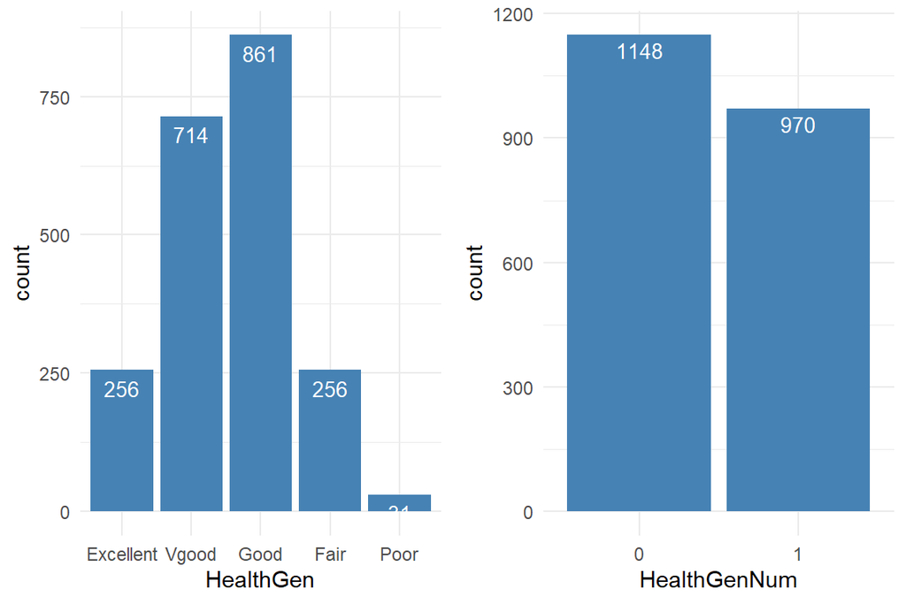

```r
par(mfrow=c(1,2))
g1 <- ggplot(dat,aes(x=HealthGen))+
  geom_bar(fill="steelblue")+
  geom_text(aes(label=..count..), stat="count", vjust=1.6, color="white", size=3.5)+
  theme_minimal()

# dichotomize into two categories: Excellent/Vgood vs others
dat$HealthGenNum = as.factor(as.numeric((dat$HealthGen == "Excellent" | dat$HealthGen == "Vgood" )))

g2 <- ggplot(dat, aes(x=HealthGenNum))+
  geom_bar(fill="steelblue")+
  geom_text(aes(label=..count..), stat="count", vjust=1.4, color="white", size=3.5)+
  theme_minimal()

ggarrange(g1,g2,ncol=2)
```

```r
#drop HealthGen in dataset
dat = dat[, !(names(dat) %in% c('HealthGen'))]
ind = names(dat)
```

First we proceed with a model with all of the factors.

```r
ind <-names(dat)
factors <- ind[!(ind %in% c('HealthGenNum'))]
model <- glm(as.formula(paste("HealthGenNum~", paste(factors,collapse='+'))), family=binomial(),
             data=dat)
summary(model)
```

```
##
## Call:
## glm(formula = as.formula(paste("HealthGenNum~", paste(factors,
##     collapse = "+"))), family = binomial(), data = dat)
##
## Deviance Residuals:
##     Min       1Q   Median       3Q      Max
## -2.1552  -0.9178  -0.4389   0.9498   2.5901
##
## Coefficients:
##                            Estimate Std. Error z value Pr(>|z|)
## (Intercept)                0.062535   0.820405   0.076 0.939240
## Gendermale                -0.132973   0.105441  -1.261 0.207269
## Age                       -0.022203   0.005203  -4.267 1.98e-05 ***
## Race1Hispanic             -0.930680   0.274507  -3.390 0.000698 ***
## Race1Mexican              -0.230778   0.247279  -0.933 0.350679
## Race1White                 0.203999   0.172065   1.186 0.235784
## Race1Other                -0.464154   0.239077  -1.941 0.052205 .
## Education9 - 11th Grade    0.435620   0.424219   1.027 0.304479
## EducationHigh School       0.810803   0.415034   1.954 0.050751 .
## EducationSome College      0.753557   0.410220   1.837 0.066216 .
## EducationCollege Grad      1.276590   0.418074   3.054 0.002262 **
## MaritalStatusLivePartner   0.346971   0.242273   1.432 0.152102
## MaritalStatusMarried      -0.151757   0.189894  -0.799 0.424194
## MaritalStatusNeverMarried -0.148367   0.216562  -0.685 0.493280
## MaritalStatusSeparated     0.281515   0.376595   0.748 0.454745
## MaritalStatusWidowed      -0.588352   0.568588  -1.035 0.300781
## HHIncome 5000-9999         0.122850   0.517870   0.237 0.812485
## HHIncome10000-14999       -0.780820   0.449198  -1.738 0.082166 .
## HHIncome15000-19999       -0.439610   0.435852  -1.009 0.313155
## HHIncome20000-24999        0.057541   0.439012   0.131 0.895721
## HHIncome25000-34999       -0.158413   0.407000  -0.389 0.697112
## HHIncome35000-44999       -0.227706   0.406469  -0.560 0.575339
## HHIncome45000-54999       -0.039547   0.411668  -0.096 0.923468
## HHIncome55000-64999       -0.136361   0.434474  -0.314 0.753632
## HHIncome65000-74999        0.064761   0.423930   0.153 0.878585
## HHIncome75000-99999        0.704710   0.403634   1.746 0.080826 .
## HHIncomemore 99999         0.335850   0.393138   0.854 0.392950
## BMI_WHO18.5_to_24.9        0.695302   0.425220   1.635 0.102016
## BMI_WHO25.0_to_29.9        0.346619   0.427096   0.812 0.417039
```

[output cut: 12 more lines]

```
## CompHrsDay2_hr             0.391611   0.205618   1.905 0.056838 .
## CompHrsDay3_hr             0.121868   0.240612   0.506 0.612510
## CompHrsDay4_hr             0.003846   0.286758   0.013 0.989299
## CompHrsDayMore_4_hr        0.155907   0.264374   0.590 0.555377
## RegularMarijYes           -0.247264   0.118241  -2.091 0.036511 *
## ---
## Signif. codes:  0 '***' 0.001 '**' 0.01 '*' 0.05 '.' 0.1 ' ' 1
##
## (Dispersion parameter for binomial family taken to be 1)
##
##     Null deviance: 2921.2  on 2117  degrees of freedom
## Residual deviance: 2380.2  on 2072  degrees of freedom
## AIC: 2472.2
##
## Number of Fisher Scoring iterations: 4
```

Notice that for variables like `MaritalStatus` and `TVHrsDay`, they didn’t contribute to any of the significant factors. Let’s further investigate on these two variable by plotting them against HealthGenNum

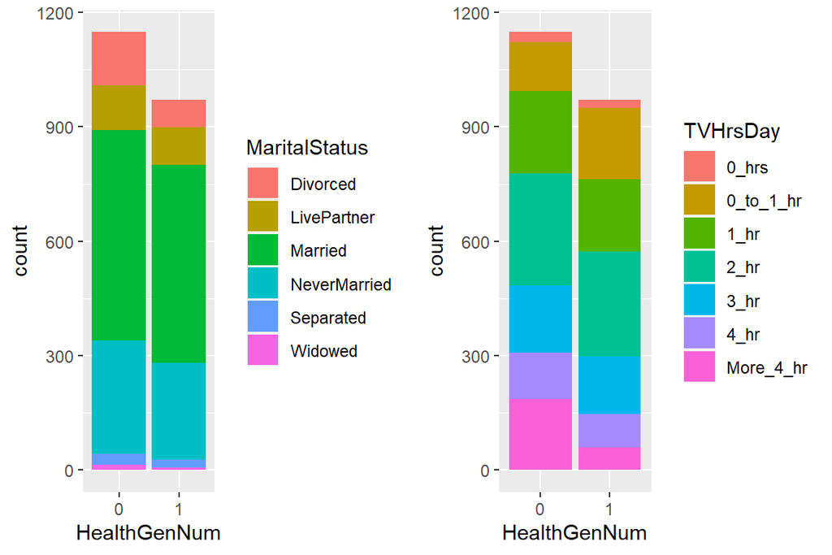

```r
g3 <- ggplot(dat)+
  geom_bar(mapping=aes(x=HealthGenNum,fill=MaritalStatus))

g4 <- ggplot(dat)+
  geom_bar(mapping=aes(x=HealthGenNum,fill=TVHrsDay))

ggarrange(g3,g4,ncol=2)
```

We can see clearly that the two variable’s distribution are roughly the same except for specific categories. Therefore, we will also be transforming these two factors into binary factors.

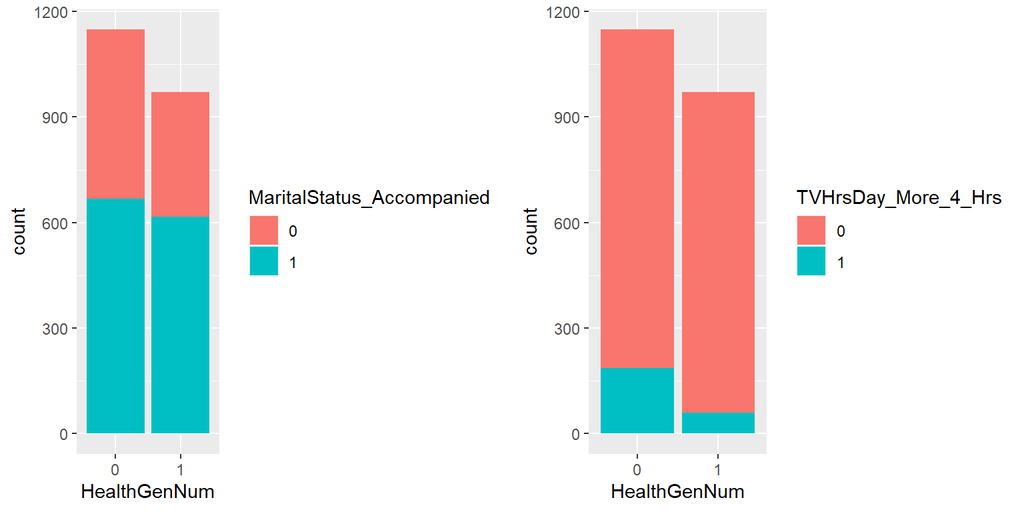

```r
# dichotomize MaritalStatus into two categories: Married/LivPartner vs NeverMarried/Separated/Widowed/Divorced
dat$MaritalStatus_Accompanied = as.factor(as.numeric((dat$MaritalStatus == "Married" | dat$MaritalStatus == "LivePartner" )))

# dichotomize TVHrsDay into two categories: More_4_Hrs vs others
dat$TVHrsDay_More_4_Hrs = as.factor(as.numeric((dat$TVHrsDay == "More_4_hr")))

g5 <- ggplot(dat)+
  geom_bar(mapping=aes(x=HealthGenNum,fill=MaritalStatus_Accompanied))

g6 <- ggplot(dat)+
  geom_bar(mapping=aes(x=HealthGenNum,fill=TVHrsDay_More_4_Hrs))

ggarrange(g5,g6,ncol=2)
```

Similarly, we also convert `BMI_WHO` into binary variable as `BMI30.0_plus VS others`

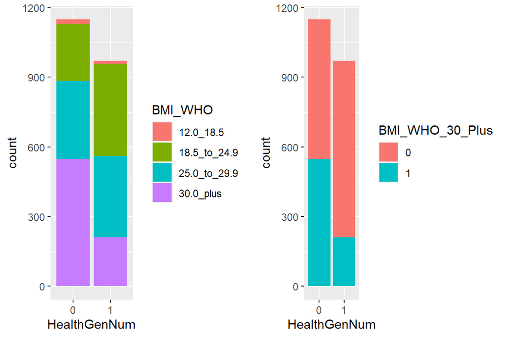

```r
g7 <- ggplot(dat)+
  geom_bar(mapping=aes(x=HealthGenNum,fill=BMI_WHO))

# dichotomize TVHrsDay into two categories: More_4_Hrs vs others
dat$BMI_WHO_30_Plus = as.factor(as.numeric((dat$BMI_WHO == "30.0_plus")))

g8 <- ggplot(dat)+
  geom_bar(mapping=aes(x=HealthGenNum,fill=BMI_WHO_30_Plus))

ggarrange(g7,g8,ncol=2)
```

Remaining factors:

```r
factors <- factors[!(factors %in% c('MaritalStatus','TVHrsDay','BMI_WHO'))]
factors <-c(factors, c("MaritalStatus_Accompanied","TVHrsDay_More_4_Hrs","BMI_WHO_30_Plus"))
factors
```

```
##  [1] "Gender"                    "Age"
##  [3] "Race1"                     "Education"
##  [5] "HHIncome"                  "Depressed"
##  [7] "SleepTrouble"              "CompHrsDay"
##  [9] "RegularMarij"              "MaritalStatus_Accompanied"
## [11] "TVHrsDay_More_4_Hrs"       "BMI_WHO_30_Plus"
```

## 3.2 Forward Selection

In this step, we add each of the variable to the null model and test it against the null model. We record their respective p values and add variables with `p value < 0.1` to the model.

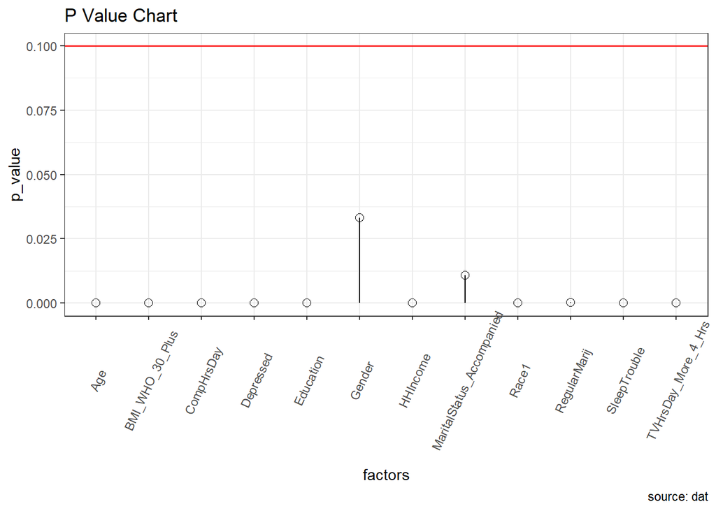

```r
##### UNIVARIATE SCREENING #####
p_value <- rep(NA, length(factors))

fit0 = glm(HealthGenNum~1, family=binomial(), data=dat)

#loop through each of the element and test the univariate model
for (i in 1:length(factors)) {
  factor = factors[i]
  fit1 = glm(as.formula(paste("HealthGenNum~", paste(factor))), family=binomial(),
             data=dat)

  p_value[[i]] <- anova(fit0, fit1, test="LRT")$"Pr(>Chi)"[2]
}

uni_df <- data.frame(factors,p_value)

# Plot
ggplot(uni_df, aes(x=factors, y=p_value)) + geom_hline(yintercept=0.1,color="red",size =0.6,alpha=0.8) +
  geom_point(size=2.5,shape=1) +
  geom_segment(aes(x=factors, xend=factors,
                   y=0, yend=p_value))+
  labs(title="P Value Chart", caption="source: dat") +
  theme_bw() + theme(axis.text.x = element_text(angle=65, vjust=0.6))
```

Variables Added:

```r
factors
```

```
##  [1] "Gender"                    "Age"
##  [3] "Race1"                     "Education"
##  [5] "HHIncome"                  "Depressed"
##  [7] "SleepTrouble"              "CompHrsDay"
##  [9] "RegularMarij"              "MaritalStatus_Accompanied"
## [11] "TVHrsDay_More_4_Hrs"       "BMI_WHO_30_Plus"
```

## 3.3 Backwards Elimination:

After adding all the significant variables to the model, we then perform backwards elimination on the multivariate mode. We take one variable out each time and test it against the full model. Again, we record their p value respectively. We use a 0.05 cut off for eliminating non-significant variables.

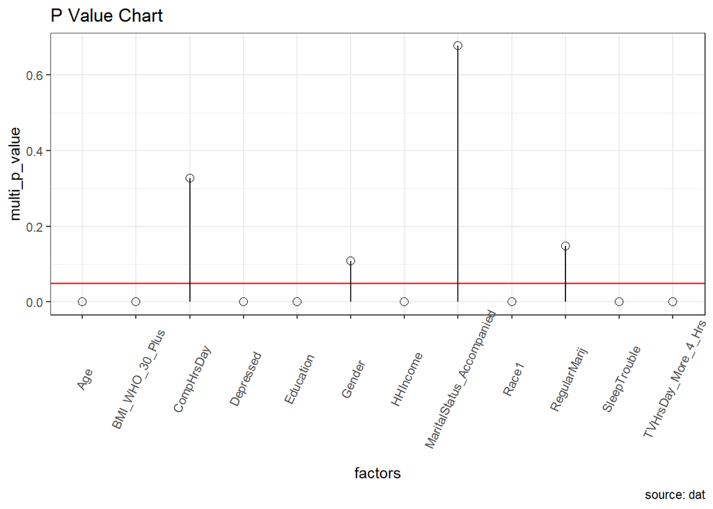

```r
##### BACKWARDS SELECTION #####

#Multivariate model with all significant variable
multi_fit1 <-glm(as.formula(paste("HealthGenNum~", paste(factors, collapse="+"))),
                 family=binomial(),data=dat)

multi_p_value <- rep(NA, length(factors))

for(i in 1:length(factors)){

  #remove the ith variable
  factors_temp <- factors[-i]

  multi_fit0<-glm(as.formula(paste("HealthGenNum~", paste(factors_temp, collapse="+"))),
                  family=binomial(),data=dat)

  multi_p_value[[i]] <- anova(multi_fit0, multi_fit1, test="LRT")$"Pr(>Chi)"[2]
}

multi_df.1 <- data.frame(factors,multi_p_value)
# Plot
ggplot(multi_df.1, aes(x=factors, y=multi_p_value)) +
  geom_hline(yintercept=0.05,color="red",size =0.6,alpha=0.8) +
  geom_segment(aes(x=factors, xend=factors,
                   y=0, yend=multi_p_value))+
  geom_point(size=2.5,shape=1) +
  labs(title="P Value Chart", caption="source: dat") +
  theme_bw() + theme(axis.text.x = element_text(angle=65, vjust=0.6))
```

```r
#Eliminated factors
kable(multi_df.1[multi_p_value >= 0.05,], caption = "Factors Eliminated") %>% kable_styling(bootstrap_options = c("striped", "condensed"), full_width = F)
```

Factors Eliminated

|  | factors | multi_p_value |
| --- | --- | --- |
| 1 | Gender | 0.1084665 |
| 8 | CompHrsDay | 0.3265096 |
| 9 | RegularMarij | 0.1470998 |
| 10 | MaritalStatus_Accompanied | 0.6776815 |

Remained variables:

```r
factors <- factors[!(factors %in% c('CompHrsDay','Gender','MaritalStatus_Accompanied','RegularMarij'))]
factors
```

```
## [1] "Age"                 "Race1"               "Education"
## [4] "HHIncome"            "Depressed"           "SleepTrouble"
## [7] "TVHrsDay_More_4_Hrs" "BMI_WHO_30_Plus"
```

## 3.4 Forward Selection with Removed Variables:

Starting with our last model from step (2), we consider re-adding each of the removed variables using forward selection, with a significance level of 0.05. We use anova to test the model from step (2) against the same model but with one of the removed variables re-added to it.

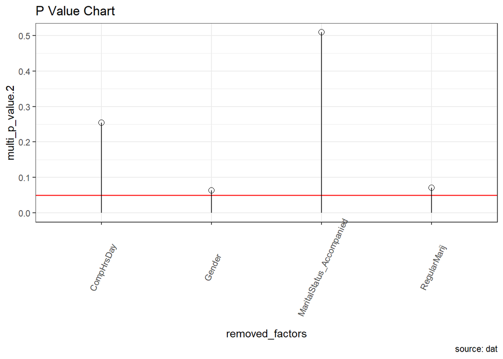

```r
removed_factors <- c("CompHrsDay", "Gender","MaritalStatus_Accompanied","RegularMarij")
multi_fit0 <-glm(as.formula(paste("HealthGenNum~", paste(factors, collapse="+"))),
                   family=binomial(),data=dat)

##### TEST RE-ADDING VARIABLES REMOVED IN BACKWARD SELECTION #####
multi_p_value.2 <- rep(NA, length(removed_factors))

for (i in 1:length(removed_factors)) {
  factors_add <- c(factors, removed_factors[i])

  # Model with a removed factor re-added
  multi_fit1<-glm(as.formula(paste("HealthGenNum~", paste(factors_add, collapse="+"))),
                  family=binomial(),data=dat)

  multi_p_value.2[[i]] <- anova(multi_fit0, multi_fit1, test="LRT")$"Pr(>Chi)"[2]

}

multi_df.2 <- data.frame(removed_factors,multi_p_value.2)

# Plot
ggplot(multi_df.2, aes(x=removed_factors, y=multi_p_value.2)) +
  geom_hline(yintercept=0.05,color="red",size =0.6,alpha=0.8) +
  geom_segment(aes(x=removed_factors, xend=removed_factors,
                   y=0, yend=multi_p_value.2))+
  geom_point(size=2.5,shape=1) +
  labs(title="P Value Chart", caption="source: dat") +
  theme_bw() + theme(axis.text.x = element_text(angle=65, vjust=0.6))
```

None of the removed variables is added.  
Significant variables:

```
## [1] "Age"                 "Race1"               "Education"
## [4] "HHIncome"            "Depressed"           "SleepTrouble"
## [7] "TVHrsDay_More_4_Hrs" "BMI_WHO_30_Plus"
```

## 3.5 Final Backward Elimination

We perform a final round of backwards elimination on all the variables at a significance level of 0.02 to remove any non-significant variables.

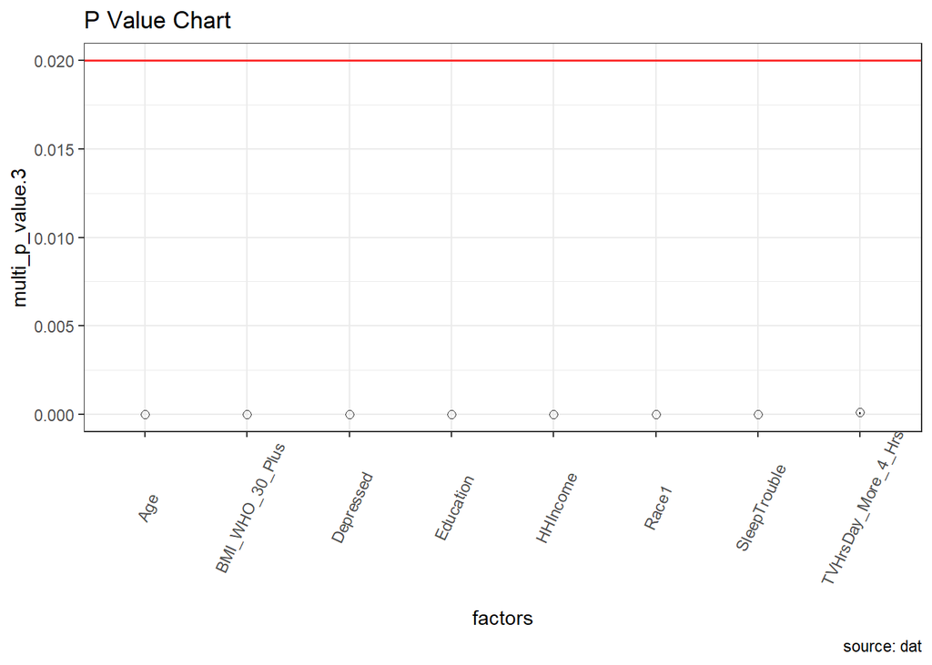

```r
#Rerun backward selection
multi_fit1 <-glm(as.formula(paste("HealthGenNum~", paste(factors, collapse="+"))),
                 family=binomial(),data=dat)

multi_p_value.3 <- rep(NA, length(factors))

for (i in 1:length(factors)) {

  factors_temp <- factors[-i]

  multi_fit0<-glm(as.formula(paste("HealthGenNum~", paste(factors_temp, collapse="+"))),
                  family=binomial(),data=dat)

  multi_p_value.3[[i]] <- anova(multi_fit0, multi_fit1, test="LRT")$"Pr(>Chi)"[2]
}

multi_df.3 <- data.frame(factors,multi_p_value.3)

# Plot
ggplot(multi_df.3, aes(x=factors, y=multi_p_value.3)) +
  geom_hline(yintercept=0.02,color="red",size =0.6,alpha=0.8) +
  geom_segment(aes(x=factors, xend=factors,
                   y=0, yend=multi_p_value.3))+
  geom_point(size=2,alpha=0.8,shape=1) +
  labs(title="P Value Chart", caption="source: dat") +
  theme_bw() + theme(axis.text.x = element_text(angle=65, vjust=0.6))
```

None of the variables are removed.

## 3.6 Final model

Let’s look at our final model at this point. The main factors included in our model are:

`Age`, `Race1`, `BMI_WHO_30_Plus`, `Depressed`, `Education`, `HHIncome`, `SleepTrouble`, `TVHrsDay_More_4_Hrs`

```r
#update dat
dat.original <- dat
dat <- dat[,c(factors,"HealthGenNum")]

#Final Model
final_fit<-glm(as.formula(paste("HealthGenNum~", paste(factors, collapse="+"))),
                  family=binomial(), data=dat)
summary(final_fit) #AIC: 2473
```

```
##
## Call:
## glm(formula = as.formula(paste("HealthGenNum~", paste(factors,
##     collapse = "+"))), family = binomial(), data = dat)
##
## Deviance Residuals:
##     Min       1Q   Median       3Q      Max
## -2.0665  -0.9339  -0.4386   0.9634   2.6846
##
## Coefficients:
##                          Estimate Std. Error z value Pr(>|z|)
## (Intercept)              0.509508   0.580644   0.877 0.380221
## Age                     -0.023015   0.004439  -5.185 2.16e-07 ***
## Race1Hispanic           -0.773381   0.270189  -2.862 0.004205 **
## Race1Mexican            -0.221439   0.241642  -0.916 0.359461
## Race1White               0.219409   0.167449   1.310 0.190092
## Race1Other              -0.436079   0.231498  -1.884 0.059602 .
## Education9 - 11th Grade  0.496925   0.418855   1.186 0.235469
## EducationHigh School     0.849893   0.407313   2.087 0.036926 *
## EducationSome College    0.882715   0.401239   2.200 0.027809 *
## EducationCollege Grad    1.398282   0.406773   3.437 0.000587 ***
## HHIncome 5000-9999       0.073347   0.505590   0.145 0.884654
## HHIncome10000-14999     -0.888245   0.436161  -2.037 0.041699 *
## HHIncome15000-19999     -0.485635   0.422143  -1.150 0.249977
## HHIncome20000-24999     -0.052172   0.424905  -0.123 0.902277
## HHIncome25000-34999     -0.226743   0.391425  -0.579 0.562404
## HHIncome35000-44999     -0.281288   0.392075  -0.717 0.473106
## HHIncome45000-54999     -0.146307   0.395467  -0.370 0.711413
## HHIncome55000-64999     -0.214256   0.416340  -0.515 0.606820
## HHIncome65000-74999     -0.076840   0.407012  -0.189 0.850257
## HHIncome75000-99999      0.595702   0.386709   1.540 0.123453
## HHIncomemore 99999       0.219996   0.374420   0.588 0.556824
## DepressedSeveral        -0.701382   0.154046  -4.553 5.29e-06 ***
## DepressedMost           -0.796777   0.239568  -3.326 0.000881 ***
## SleepTroubleYes         -0.809664   0.121421  -6.668 2.59e-11 ***
## TVHrsDay_More_4_Hrs1    -0.664645   0.175122  -3.795 0.000147 ***
## BMI_WHO_30_Plus1        -1.188049   0.107651 -11.036  < 2e-16 ***
## ---
## Signif. codes:  0 '***' 0.001 '**' 0.01 '*' 0.05 '.' 0.1 ' ' 1
##
## (Dispersion parameter for binomial family taken to be 1)
##
##     Null deviance: 2921.2  on 2117  degrees of freedom
## Residual deviance: 2421.9  on 2092  degrees of freedom
## AIC: 2473.9
##
## Number of Fisher Scoring iterations: 4
```

Looking at the coefficient and significance level for each categories, we conclude the following:

- Positive Influence
  - Starting from high school, a higher level of education level indicates a stronger positive influence on our health.
- Negative Influence
  - Age represent a definitive, but trivial influence on our health.
  - Being Hispanic also represents a higher risk of having a negative influence on the health. This might have something to do with the Hispanic food culture and social status.
  - BMI over 30 is a very strong indicator for a fairer health, considering it’s coefficient being -1.1.
  - Lifestyle indicators such as `More than 4 hours of TV per day`, `Having sleep troubles` and `Being some degree of depressed` all predicts a result of fairer health.

# 4 Interaction terms

Now we finished analyzing the final model, but could there be any factors we are missing on? What if when two factors combined together they can also significantly influence our result? To answer this question, we will be looking at interaction terms, namely the interaction between any two factors.  
Among the 8 final variables, there are unique 28 pairwise interaction terms. We compare `A+B` with `A+B+A*B` for each pair and using forward selection with a significance level of 0.01 to filter our result.

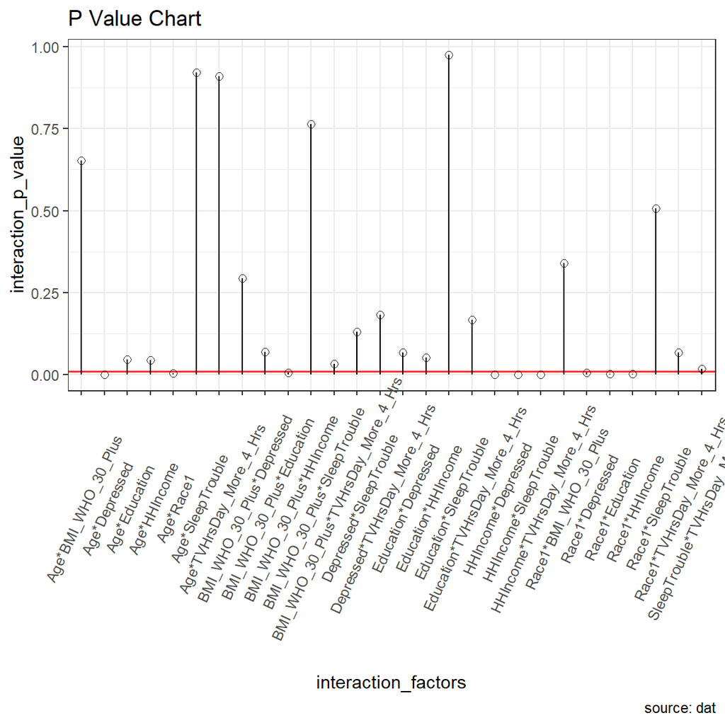

```r
### Generate interaction terms
final_factors <- c("Age", "Race1", "BMI_WHO_30_Plus", "Education", "HHIncome", "Depressed", "SleepTrouble", "TVHrsDay_More_4_Hrs")

len_ff = length(final_factors)
interaction_p_value <- rep(NA, len_ff*(len_ff-1)*0.5)
interaction_factors <- character()

count <- 0
for (i in 1:(len_ff-1)) {
  for (j in (i+1):len_ff){

    #model: A+B
    interaction <- c(final_factors[i],final_factors[j])
    final_fit0<- glm(as.formula(paste("HealthGenNum~",paste(interaction,collapse="+"))),
                family=binomial(),data=dat)

    #model: A+B+A*B
    interaction_factors <- c(interaction_factors, paste(interaction, collapse="*"))

    count <- count+1
    final_temp <- c(interaction,interaction_factors[count])
    final_fit1 <- glm(as.formula(paste("HealthGenNum~", paste(final_temp, collapse="+"))),
                           family=binomial(),data=dat)

    interaction_p_value[[count]] <- anova(final_fit0,final_fit1,test ="LRT")$"Pr(>Chi)"[2]

  }
}

interaction_df <- data.frame(interaction_factors,interaction_p_value)

# Plot
ggplot(interaction_df, aes(x=interaction_factors, y=interaction_p_value)) +
  geom_hline(yintercept=0.01,color="red",size =0.6,alpha=0.8) +
  geom_segment(aes(x=interaction_factors, xend=interaction_factors,
                   y=0, yend=interaction_p_value))+
  geom_point(size=2,alpha=0.8,shape=1) +
  labs(title="P Value Chart", caption="source: dat") +
  theme_bw() + theme(axis.text.x = element_text(angle=65, vjust=0.6))
```

```r
kable(interaction_df[interaction_p_value < 0.01,], caption = "Interaction Terms Added") %>% kable_styling(bootstrap_options = c("striped", "condensed"), full_width = F)
```

Interaction Terms Added

|  | interaction_factors | interaction_p_value |
| --- | --- | --- |
| 1 | Age*Race1 | 0.0040948 |
| 5 | Age*Depressed | 0.0001387 |
| 9 | Race1*Education | 0.0026699 |
| 10 | Race1*HHIncome | 0.0014492 |
| 11 | Race1*Depressed | 0.0058563 |
| 15 | BMI_WHO_30_Plus*HHIncome | 0.0062821 |
| 23 | HHIncome*Depressed | 0.0001400 |
| 24 | HHIncome*SleepTrouble | 0.0001805 |
| 25 | HHIncome*TVHrsDay_More_4_Hrs | 0.0001821 |

```r
interaction_added <- interaction_df[interaction_p_value < 0.01,]
```

## 4.1 Final model with interaction terms:

Here is our final model with additional interaction terms added.

```r
#
final_w_int <- c(final_factors,as.character(interaction_added$interaction_factors))
final_w_int
```

```
##  [1] "Age"                          "Race1"
##  [3] "BMI_WHO_30_Plus"              "Education"
##  [5] "HHIncome"                     "Depressed"
##  [7] "SleepTrouble"                 "TVHrsDay_More_4_Hrs"
##  [9] "Age*Race1"                    "Age*Depressed"
## [11] "Race1*Education"              "Race1*HHIncome"
## [13] "Race1*Depressed"              "BMI_WHO_30_Plus*HHIncome"
## [15] "HHIncome*Depressed"           "HHIncome*SleepTrouble"
## [17] "HHIncome*TVHrsDay_More_4_Hrs"
```

```r
final_fit_int<-glm(as.formula(paste("HealthGenNum~", paste(final_w_int, collapse="+"))),
                  family=binomial(), data=dat)
summary(final_fit_int)
```

```
##
## Call:
## glm(formula = as.formula(paste("HealthGenNum~", paste(final_w_int,
##     collapse = "+"))), family = binomial(), data = dat)
##
## Deviance Residuals:
##     Min       1Q   Median       3Q      Max
## -2.4541  -0.8540  -0.0260   0.8506   3.2183
##
## Coefficients:
##                                            Estimate Std. Error z value Pr(>|z|)
## (Intercept)                               -15.90321 2207.50122  -0.007  0.99425
## Age                                        -0.01660    0.01584  -1.048  0.29454
## Race1Hispanic                             -14.79748 3169.27638  -0.005  0.99627
## Race1Mexican                               12.78209 2207.50169   0.006  0.99538
## Race1White                                 16.05320 2207.50149   0.007  0.99420
## Race1Other                                 -4.15803 4530.38985  -0.001  0.99927
## BMI_WHO_30_Plus1                           -1.74515    1.28942  -1.353  0.17592
## Education9 - 11th Grade                    16.32494 2207.50090   0.007  0.99410
## EducationHigh School                       17.17020 2207.50084   0.008  0.99379
## EducationSome College                      17.94080 2207.50083   0.008  0.99352
## EducationCollege Grad                      18.07639 2207.50083   0.008  0.99347
## HHIncome 5000-9999                         -1.11343    1.59781  -0.697  0.48590
## HHIncome10000-14999                        -1.92235    1.50278  -1.279  0.20083
## HHIncome15000-19999                        -0.28904    1.48577  -0.195  0.84575
## HHIncome20000-24999                         0.96906    1.60521   0.604  0.54605
## HHIncome25000-34999                        -0.35046    1.36444  -0.257  0.79729
## HHIncome35000-44999                        -0.63522    1.37824  -0.461  0.64488
## HHIncome45000-54999                        -1.10182    1.42316  -0.774  0.43881
## HHIncome55000-64999                         1.30696    1.82871   0.715  0.47480
## HHIncome65000-74999                         1.32151    1.53248   0.862  0.38850
## HHIncome75000-99999                        -0.43236    1.37020  -0.316  0.75234
## HHIncomemore 99999                         -0.59293    1.33036  -0.446  0.65582
## DepressedSeveral                            0.99284    1.47926   0.671  0.50211
## DepressedMost                              -2.64133    3.56579  -0.741  0.45885
## SleepTroubleYes                            -0.09945    0.85566  -0.116  0.90747
## TVHrsDay_More_4_Hrs1                        0.43815    1.60932   0.272  0.78542
## Age:Race1Hispanic                          -0.04377    0.03338  -1.311  0.18974
## Age:Race1Mexican                            0.05574    0.02589   2.153  0.03133
## Age:Race1White                             -0.01499    0.01696  -0.884  0.37690
```

[output cut: 277 more lines]

```
## HHIncome45000-54999:TVHrsDay_More_4_Hrs1
## HHIncome55000-64999:TVHrsDay_More_4_Hrs1
## HHIncome65000-74999:TVHrsDay_More_4_Hrs1
## HHIncome75000-99999:TVHrsDay_More_4_Hrs1
## HHIncomemore 99999:TVHrsDay_More_4_Hrs1
## ---
## Signif. codes:  0 '***' 0.001 '**' 0.01 '*' 0.05 '.' 0.1 ' ' 1
##
## (Dispersion parameter for binomial family taken to be 1)
##
##     Null deviance: 2921.2  on 2117  degrees of freedom
## Residual deviance: 2138.2  on 1963  degrees of freedom
## AIC: 2448.2
##
## Number of Fisher Scoring iterations: 16
```

Looking at this model, we had some deeper interesting insight into our health.

- Positive Influence
  - Races combine with a high income level is a strong indicator for good health.
  - Age with most of the time depressed surprisingly is a positive influence to our health.
- Negative Influence
  - HHIncome between 20000 and 24999 and sleep trouble is a bad combination to our health. I suspect participant at this situation mostly having hard labor jobs. And having sleep trouble is not helping with their work as well as their health.
  - `DepressedMost` and `SleepTroubleYes` contribute to most of the significant negative interaction term.

# 5 Model evaluation with ROC, AUC, and CV

Now that we have our final model with and without interaction terms, we would like to assess these two models. We will be looking at r-squared, ROC/AUC and cross-validation error.

## 5.1 R-squared

R-squared is the proportion of the variance in the dependent variable that is predictable from the independent variable(s). [(Wiki)](https://en.wikipedia.org/wiki/Coefficient_of_determination)

```r
# Compute generalized r^2
all_fit_rsq = 1-exp(logLik(final_fit)/nrow(dat))
print("R-squared for final model: ")
```

```
## [1] "R-squared for final model: "
```

```r
all_fit_rsq
```

```
## 'log Lik.' 0.4354599 (df=26)
```

```r
all_fit_rsq_int = 1-exp(logLik(final_fit_int)/nrow(dat))
print("R-squared for final model with interaction: ")
```

```
## [1] "R-squared for final model with interaction: "
```

```r
all_fit_rsq_int
```

```
## 'log Lik.' 0.3963611 (df=155)
```

According to the R-squared values, the final model can explain more of the variance than the model with interactions. However, both of them only explain about 40% of the variance. One reasons might be that since we transform the `HealthGen` variable to a binary variable, there’s an inevitable loss in information. Also another explanation would be that we are still missing some important factors in our dataset.

## 5.2 ROC/AUC

A receiver operating characteristic curve, or `ROC curve`, is a graphical plot that illustrates the diagnostic ability of a binary classifier system as its discrimination threshold is varied.[(Wiki)](https://en.wikipedia.org/wiki/Receiver_operating_characteristic).ROC curves are used to show in a graphical way to trade offs between sensitivity (true positives) and (1-specificity)(false positives).

> The best possible prediction method would yield a point in the upper left corner or coordinate (0,1) of the ROC space, representing 100% sensitivity (no false negatives) and 100% specificity (no false positives). The (0,1) point is also called a perfect classification. A random guess would give a point along a diagonal line (the so-called line of no-discrimination) from the left bottom to the top right corners (regardless of the positive and negative base rates).[(Wiki,15)](https://en.wikipedia.org/wiki/Receiver_operating_characteristic)

The area under the the ROC curve, `AUC` gives us the idea of how beneficial the model is. The greater area the AUC is, the more useful the test is.

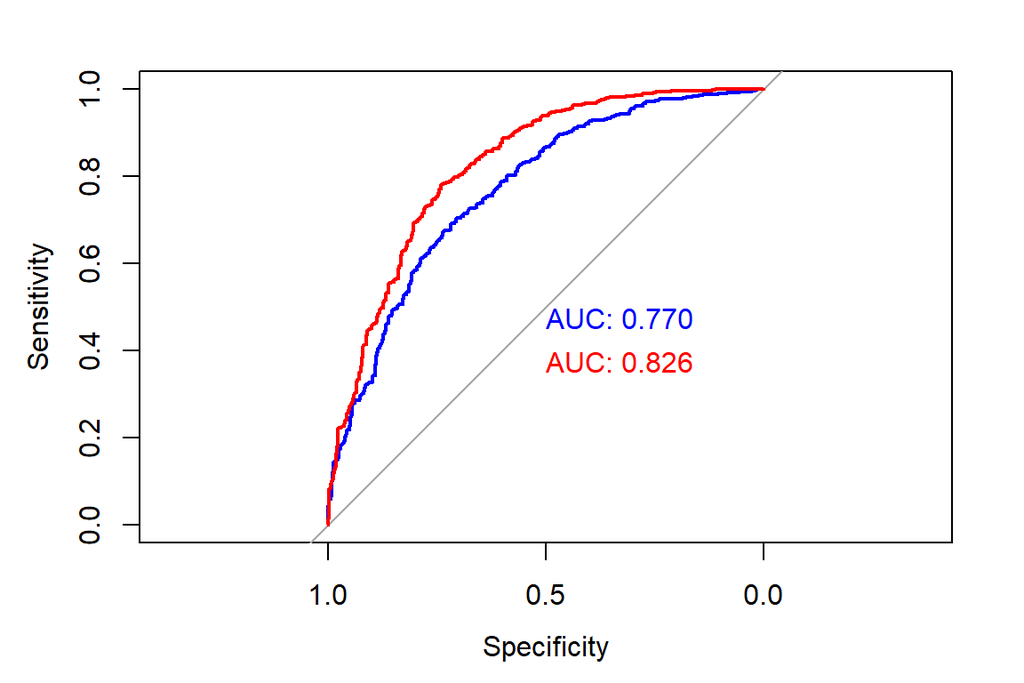

```r
plot.roc(dat$HealthGenNum, predict(final_fit, type = "response"),print.auc=TRUE, col="blue")
plot.roc(dat$HealthGenNum, predict(final_fit_int, type = "response"),print.auc=TRUE,col="red",
     print.auc.y=0.4,add=TRUE)
```

Here the blue line represents the ROC curve for the final model, and the red line represents for the final model with interaction terms.  
According to the plot, final model with interaction terms actually gives us a better prediction of the outcome. And to further investigate on this idea, we will employ `cross-validation` on the two models.

## 5.3 Cross-validation

. Validation involves splitting the dataset into training and testing two parts. We used the training set to train our model and the testing set to evaluate our model with unseen data. This can help preventing the model from over-fitting with the data. Cross-validation is using different splitting of the training/test set every time of the same dataset to do the validation process.

```r
k = 10
set.seed(123)
folds<-cvFolds(nrow(dat), K=k)
auc = numeric(length=k)
auc_int = numeric(length=k)
for(i in 1:k) {
  mov.train = dat[folds$subsets[folds$which !=i],]
  mov.test = dat[folds$subsets[folds$which == i],]
  final_fit = glm(as.formula(paste("HealthGenNum~", paste(factors, collapse="+"))), family=binomial(), data=mov.train)
  final_fit_int = glm(as.formula(paste("HealthGenNum~", paste(final_w_int, collapse="+"))), family=binomial(), data=mov.train)
  auc[i]=auc(mov.test$HealthGenNum, predict(final_fit, newdata = mov.test,type="response"))
  auc_int[i]=auc(mov.test$HealthGenNum, predict(final_fit_int, newdata = mov.test,type="response"))
}


print("Auc for the final model:")
```

```
## [1] "Auc for the final model:"
```

```r
summary(auc)
```

```
##    Min. 1st Qu.  Median    Mean 3rd Qu.    Max.
##  0.7082  0.7407  0.7655  0.7586  0.7753  0.7981
```

```r
print("Average auc for the final model with interactions:")
```

```
## [1] "Average auc for the final model with interactions:"
```

```r
summary(auc_int)
```

```
##    Min. 1st Qu.  Median    Mean 3rd Qu.    Max.
##  0.7096  0.7404  0.7555  0.7572  0.7810  0.7874
```

We can see that the interaction model are not exactly more accurate than the final model. Indeed, the two model performs similarly for an average auc of 75.8% throughout 10 folds cross-validation.  
We conclude that the two models are not statistical significantly different from each other.

# 6 Classification Tree

```r
tree_dat <- dat.original
factors_tree <- names(dat.original)

factors_tree <- factors_tree[!(factors_tree  %in% c("HealthGenNum"))]
print(factors_tree)
```

```
##  [1] "Gender"                    "Age"
##  [3] "Race1"                     "Education"
##  [5] "MaritalStatus"             "HHIncome"
##  [7] "BMI_WHO"                   "Depressed"
##  [9] "SleepTrouble"              "TVHrsDay"
## [11] "CompHrsDay"                "RegularMarij"
## [13] "MaritalStatus_Accompanied" "TVHrsDay_More_4_Hrs"
## [15] "BMI_WHO_30_Plus"
```

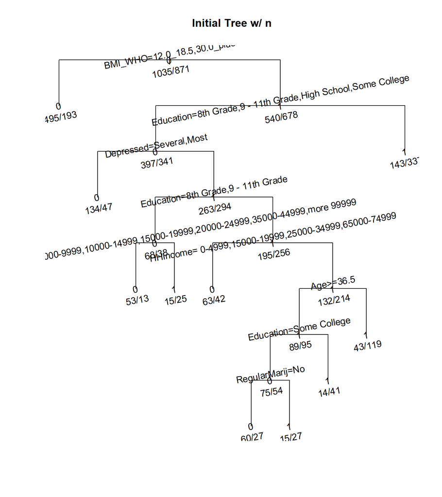

```r
#Initial Tree
set.seed(123)
# Split the data into two parts, training (80%) and testing (20%).
# A cross-validation will be performed on the training part later.
train=sample.int(nrow(tree_dat),floor(nrow(tree_dat)*0.9))
test=(1:nrow(tree_dat))[-train]

multi_fit_tree=rpart(as.formula(paste("HealthGenNum~",paste(factors_tree,collapse="+"))), data=tree_dat,subset=train)

#plot tree
plot(multi_fit_tree, uniform=TRUE, main="Initial Tree w/ n")
text(multi_fit_tree, srt=10, pretty = 0, use.n=TRUE, all=TRUE)
```

```r
#cptable
kable(multi_fit_tree$cptable)%>%
  kable_styling(bootstrap_options = c("striped", "condensed"),
                full_width = F, position = "center")
```

| CP | nsplit | rel error | xerror | xstd |
| --- | --- | --- | --- | --- |
| 0.1584386 | 0 | 1.0000000 | 1.0000000 | 0.0249689 |
| 0.0642939 | 1 | 0.8415614 | 0.8415614 | 0.0243849 |
| 0.0355913 | 2 | 0.7772675 | 0.8082664 | 0.0241913 |
| 0.0344432 | 3 | 0.7416762 | 0.8025258 | 0.0241553 |
| 0.0241102 | 4 | 0.7072331 | 0.7921929 | 0.0240886 |
| 0.0120551 | 5 | 0.6831228 | 0.7278990 | 0.0236161 |
| 0.0114811 | 8 | 0.6452354 | 0.7233065 | 0.0235785 |
| 0.0100000 | 9 | 0.6337543 | 0.7187141 | 0.0235403 |

Not so surprisingly, the most important indicator is our BMI. The order of importance goes like this: BMI_WHO > Education >Depressed > HHIncome > Age > RegularMarij. Interestingly enough, races are not included in our tree model. The result is roughly in accordance with our selection of factors in our final model.  
Now that we have our tree, but it seems too complicated, next we will be looking at ways to improve our tree.

## 6.1 Tree Pruning

> Pruning is a data compression technique in machine learning and search algorithms that reduces the size of decision trees by removing sections of the tree that are non-critical and redundant to classify instances. Pruning reduces the complexity of the final classifier, and hence improves predictive accuracy by the reduction of over-fitting. [(Wiki)](https://en.wikipedia.org/wiki/Decision_tree_pruning)

In this study we will be comparing two methods of pruning. There are usually two approaches to select the optimal cp (complexity parameter)

- Select the cp which provides the smallest xerror, if there are multiple cp’s providing the smallest xerror, choose the largest one among them.
- Select the largest cp such that xerror<min(error)+xstd, this is suggested in help(plotcp).

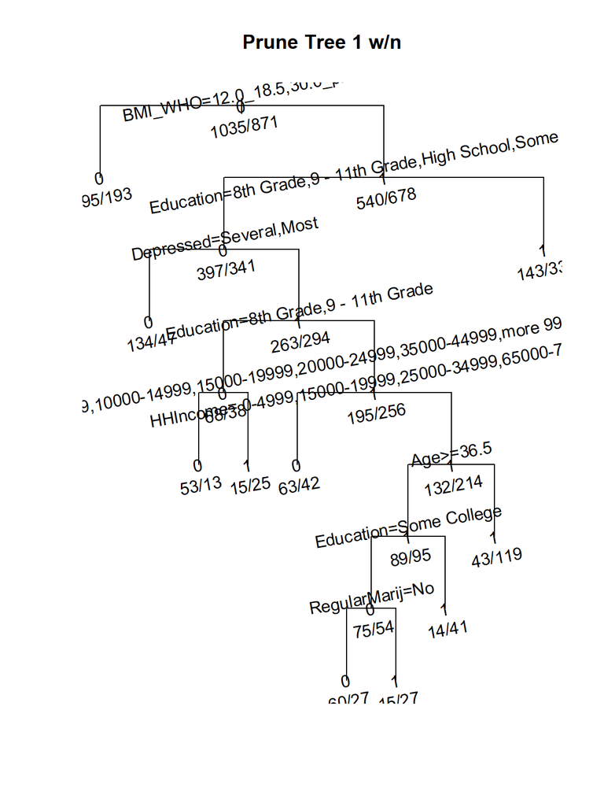

```r
#Prune Approach 1
cp1=multi_fit_tree$cptable[which.min(multi_fit_tree$cptable[,"xerror"]),"CP"]
multi_fit_prune1=prune(multi_fit_tree, cp=cp1)

plot(multi_fit_prune1, uniform=TRUE, main="Prune Tree 1 w/n")
text(multi_fit_prune1, srt=10, pretty=0, use.n=TRUE,  all=TRUE)
```

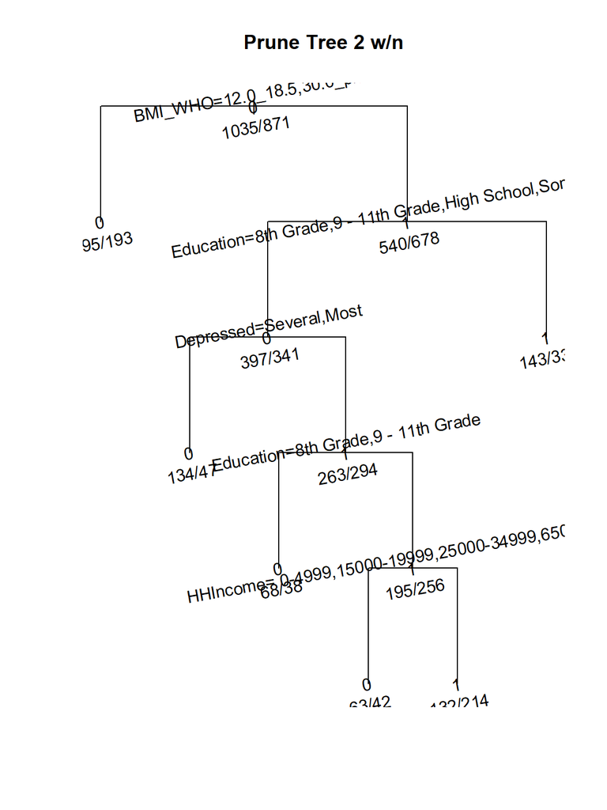

```r
#Prune Approach 2
cp2=multi_fit_tree$cptable[min(which(multi_fit_tree$cptable[,"xerror"]<=min(multi_fit_tree$cptable[,"xerror"])+multi_fit_tree$cptable[,"xstd"])),"CP"]
multi_fit_prune2=prune(multi_fit_tree, cp=cp2)

plot(multi_fit_prune2, uniform=TRUE, main="Prune Tree 2 w/n")
text(multi_fit_prune2, srt=10, pretty=0, all=TRUE, use.n=TRUE)
```

```r
kable(multi_fit_prune1$cptable)%>%
  kable_styling(bootstrap_options = c("striped", "condensed"),
                full_width = F, position = "center")
```

| CP | nsplit | rel error | xerror | xstd |
| --- | --- | --- | --- | --- |
| 0.1584386 | 0 | 1.0000000 | 1.0000000 | 0.0249689 |
| 0.0642939 | 1 | 0.8415614 | 0.8415614 | 0.0243849 |
| 0.0355913 | 2 | 0.7772675 | 0.8082664 | 0.0241913 |
| 0.0344432 | 3 | 0.7416762 | 0.8025258 | 0.0241553 |
| 0.0241102 | 4 | 0.7072331 | 0.7921929 | 0.0240886 |
| 0.0120551 | 5 | 0.6831228 | 0.7278990 | 0.0236161 |
| 0.0114811 | 8 | 0.6452354 | 0.7233065 | 0.0235785 |
| 0.0100000 | 9 | 0.6337543 | 0.7187141 | 0.0235403 |

```r
kable(multi_fit_prune2$cptable)%>%
  kable_styling(bootstrap_options = c("striped", "condensed"),
                full_width = F, position = "center")
```

| CP | nsplit | rel error | xerror | xstd |
| --- | --- | --- | --- | --- |
| 0.1584386 | 0 | 1.0000000 | 1.0000000 | 0.0249689 |
| 0.0642939 | 1 | 0.8415614 | 0.8415614 | 0.0243849 |
| 0.0355913 | 2 | 0.7772675 | 0.8082664 | 0.0241913 |
| 0.0344432 | 3 | 0.7416762 | 0.8025258 | 0.0241553 |
| 0.0241102 | 4 | 0.7072331 | 0.7921929 | 0.0240886 |
| 0.0120551 | 5 | 0.6831228 | 0.7278990 | 0.0236161 |

In our case, approach 2 has significantly simplifying our tree down to 5 levels, while approach 1 has kept our initial tree. Looking at the cp table, the two tree seems perform similarly on our data, but let’s try them out with cross-validation again.

## 6.2 Cross-validation

```r
##Testing Error repeated 10 times
err_test3=numeric()
err_test4=numeric()
err_test_guess=numeric()
for (b in 1:10){
  #split dataset
  trainT=sample.int(nrow(tree_dat),floor(nrow(tree_dat)*0.9))
  testT=(1:nrow(tree_dat))[-trainT]
  #build tree and prune w/ approach 1
  multi_fitT=rpart(as.formula(paste("HealthGenNum~",paste(factors_tree,collapse="+"))), data=tree_dat, subset=trainT)
  cp3=multi_fitT$cptable[which.min(multi_fitT$cptable[,"xerror"]),"CP"]
  multi_fit_prune3=prune(multi_fitT, cp=cp3)
  #calculate test error
  predict_table3=table(predict(multi_fit_prune3,newdata=tree_dat[testT,],type="class"),tree_dat$HealthGenNum[testT])
  err_test3[b]=1-sum(diag(predict_table3))/sum(predict_table3)
  #prune with approach 2
  cp4=multi_fitT$cptable[min(which(multi_fitT$cptable[,"xerror"]<=min(multi_fitT$cptable[,"xerror"])+multi_fitT$cptable[,"xstd"])),"CP"]
  multi_fit_prune4=prune(multi_fitT, cp=cp4)
  #calculate test error
  predict_table4=table(predict(multi_fit_prune4,newdata=tree_dat[testT,],type="class"),tree_dat$HealthGenNum[testT])
  err_test4[b]=1-sum(diag(predict_table4))/sum(predict_table4)

  err_test_guess[b]=min(prop.table(table(tree_dat$HealthGenNum[testT])))
}
print("Average Relative Error for Approach 1: ")
```

```
## [1] "Average Relative Error for Approach 1: "
```

```r
mean(err_test3)/mean(err_test_guess)
```

```
## [1] 0.7955272
```

```r
print("Average Relative Error for Approach 2: ")
```

```
## [1] "Average Relative Error for Approach 2: "
```

```r
mean(err_test4)/mean(err_test_guess)
```

```
## [1] 0.8093717
```

The two models perform similarly after 10 tests. So essentially they achieve the same results.  
Notice that even after pruning, the relative error compared to majority voting is still relative high for both our model. This might be because we did not include any of the interaction terms.

# 7 Conclusion

In conclusion, by running `Logistic Regression` on our model, we had a few discoveries.

- A bad lifestyle is detrimental to our health. BMI over 30, watching TV for more than 4 hours.day, depression, sleeping troubles are almost equivalent to having a fairer health condition.
- On the contrary, factors leading to a good health condition are not so clear. Our model suggest a combination of higher education level, higher household income might lead to a healthier environments, but they are not as deciding as the bad lifestyles.
- From these two observation, we can conclude that to achieve better health, the most important thing to do is to live a good lifestyle.

## 7.1 Limitations to Analysis

- Since we have a large number of variables for our model, we had to use extreme p-value conditions (<0.01) to narrow down the number of variables. However, one of the possible trade-offs is that our model might become over-fitting.
- At the beginning of screening, we decided to transform three of the variables into binary variables due to multiple of levels. Although by doing so we are forcing the model to focusing on more important categories, we are also suffering from the loss of information due to the process.